# Act Report

## Data Analysis and Visualization.

```python
# Import necessary packages
import numpy as np
import pandas as pd
import matplotlib.pyplot as plt
import seaborn as sns
%matplotlib inline
```

```python
# Read in the csv file and vgiew first 5 rows
df = pd.read_csv('twitter_archive_master.csv')
df.head()
```

|  | tweet_id | full_text | name | stage | rating_ratio | retweet_count | favorite_count | rating_numerator | rating_denominator | img_num | ... | p2 | p2_conf | p2_dog | p3 | p3_conf | p3_dog | date | time | source | jpg_url |
| --- | --- | --- | --- | --- | --- | --- | --- | --- | --- | --- | --- | --- | --- | --- | --- | --- | --- | --- | --- | --- | --- |
| 0 | 892420643555336193 | This is Phineas. He's a mystical boy. Only eve... | Phineas | NaN | 1.3 | 7024 | 33863 | 13.0 | 10.0 | 1 | ... | Bagel | 0.085851 | False | Banana | 0.076110 | False | 2017-08-01 | 16:23:56 | Twitter for iPhone | https://pbs.twimg.com/media/DGKD1-bXoAAIAUK.jpg |
| 1 | 892177421306343426 | This is Tilly. She's just checking pup on you.... | Tilly | NaN | 1.3 | 5305 | 29365 | 13.0 | 10.0 | 1 | ... | Pekinese | 0.090647 | True | Papillon | 0.068957 | True | 2017-08-01 | 00:17:27 | Twitter for iPhone | https://pbs.twimg.com/media/DGGmoV4XsAAUL6n.jpg |
| 2 | 891815181378084864 | This is Archie. He is a rare Norwegian Pouncin... | Archie | NaN | 1.2 | 3488 | 22088 | 12.0 | 10.0 | 1 | ... | Malamute | 0.078253 | True | Kelpie | 0.031379 | True | 2017-07-31 | 00:18:03 | Twitter for iPhone | https://pbs.twimg.com/media/DGBdLU1WsAANxJ9.jpg |
| 3 | 891689557279858688 | This is Darla. She commenced a snooze mid meal... | Darla | NaN | 1.3 | 7237 | 36989 | 13.0 | 10.0 | 1 | ... | Labrador Retriever | 0.168086 | True | Spatula | 0.040836 | False | 2017-07-30 | 15:58:51 | Twitter for iPhone | https://pbs.twimg.com/media/DF_q7IAWsAEuuN8.jpg |
| 4 | 891327558926688256 | This is Franklin. He would like you to stop ca... | Franklin | NaN | 1.2 | 7775 | 35364 | 12.0 | 10.0 | 2 | ... | English Springer | 0.225770 | True | German Short-Haired Pointer | 0.175219 | True | 2017-07-29 | 16:00:24 | Twitter for iPhone | https://pbs.twimg.com/media/DF6hr6BUMAAzZgT.jpg |

5 rows × 23 columns

```python
df.info()
```

```
<class 'pandas.core.frame.DataFrame'>
RangeIndex: 1908 entries, 0 to 1907
Data columns (total 23 columns):
 #   Column              Non-Null Count  Dtype
---  ------              --------------  -----
 0   tweet_id            1908 non-null   int64
 1   full_text           1908 non-null   object
 2   name                1296 non-null   object
 3   stage               309 non-null    object
 4   rating_ratio        1908 non-null   float64
 5   retweet_count       1908 non-null   int64
 6   favorite_count      1908 non-null   int64
 7   rating_numerator    1908 non-null   float64
 8   rating_denominator  1908 non-null   float64
 9   img_num             1908 non-null   int64
 10  p1                  1908 non-null   object
 11  p1_conf             1908 non-null   float64
 12  p1_dog              1908 non-null   bool
 13  p2                  1908 non-null   object
 14  p2_conf             1908 non-null   float64
 15  p2_dog              1908 non-null   bool
 16  p3                  1908 non-null   object
 17  p3_conf             1908 non-null   float64
 18  p3_dog              1908 non-null   bool
 19  date                1908 non-null   object
 20  time                1908 non-null   object
 21  source              1908 non-null   object
 22  jpg_url             1908 non-null   object
dtypes: bool(3), float64(6), int64(4), object(10)
memory usage: 303.8+ KB
```

```python
df.describe()
```

|  | tweet_id | rating_ratio | retweet_count | favorite_count | rating_numerator | rating_denominator | img_num | p1_conf | p2_conf | p3_conf |
| --- | --- | --- | --- | --- | --- | --- | --- | --- | --- | --- |
| count | 1.908000e+03 | 1908.000000 | 1908.000000 | 1908.000000 | 1908.000000 | 1908.0 | 1908.000000 | 1908.000000 | 1.908000e+03 | 1.908000e+03 |
| mean | 7.348976e+17 | 1.164873 | 2049.387317 | 7226.901468 | 11.648732 | 10.0 | 1.202306 | 0.592905 | 1.343463e-01 | 6.025894e-02 |
| std | 6.777901e+16 | 4.154405 | 3629.863505 | 10658.512672 | 41.544051 | 0.0 | 0.559941 | 0.273197 | 1.006359e-01 | 5.095809e-02 |
| min | 6.660209e+17 | 0.000000 | 11.000000 | 66.000000 | 0.000000 | 10.0 | 1.000000 | 0.044333 | 1.011300e-08 | 1.740170e-10 |
| 25% | 6.754953e+17 | 1.000000 | 481.750000 | 1565.000000 | 10.000000 | 10.0 | 1.000000 | 0.359779 | 5.419487e-02 | 1.609287e-02 |
| 50% | 7.070489e+17 | 1.100000 | 1034.500000 | 3304.500000 | 11.000000 | 10.0 | 1.000000 | 0.587222 | 1.172595e-01 | 4.967815e-02 |
| 75% | 7.862663e+17 | 1.200000 | 2339.500000 | 8778.000000 | 12.000000 | 10.0 | 1.000000 | 0.847063 | 1.948745e-01 | 9.157912e-02 |
| max | 8.924206e+17 | 177.600000 | 70907.000000 | 145012.000000 | 1776.000000 | 10.0 | 4.000000 | 1.000000 | 4.880140e-01 | 2.734190e-01 |

## Analysis 1

### P1

```python
# Qauntitative analysis of P1
df['p1'].describe()
```

```
count                 1908
unique                 369
top       Golden Retriever
freq                   125
Name: p1, dtype: object
```

Golden Retriever is the most predicted P1 dog breed at 125 amongst 369 unique dog breeds.

```python
# Value counts of P1
df['p1'].value_counts()
```

```
Golden Retriever      125
Pembroke               87
Labrador Retriever     84
Chihuahua              75
Pug                    52
                     ...
Nail                    1
Timber Wolf             1
Espresso                1
Bib                     1
Desktop Computer        1
Name: p1, Length: 369, dtype: int64
```

```python
# Filter values of P1 greater than 25
df.groupby('p1').filter(lambda x: len(x) >= 25)
```

|  | tweet_id | full_text | name | stage | rating_ratio | retweet_count | favorite_count | rating_numerator | rating_denominator | img_num | ... | p2 | p2_conf | p2_dog | p3 | p3_conf | p3_dog | date | time | source | jpg_url |
| --- | --- | --- | --- | --- | --- | --- | --- | --- | --- | --- | --- | --- | --- | --- | --- | --- | --- | --- | --- | --- | --- |
| 1 | 892177421306343426 | This is Tilly. She's just checking pup on you.... | Tilly | NaN | 1.3 | 5305 | 29365 | 13.0 | 10.0 | 1 | ... | Pekinese | 0.090647 | True | Papillon | 0.068957 | True | 2017-08-01 | 00:17:27 | Twitter for iPhone | https://pbs.twimg.com/media/DGGmoV4XsAAUL6n.jpg |
| 2 | 891815181378084864 | This is Archie. He is a rare Norwegian Pouncin... | Archie | NaN | 1.2 | 3488 | 22088 | 12.0 | 10.0 | 1 | ... | Malamute | 0.078253 | True | Kelpie | 0.031379 | True | 2017-07-31 | 00:18:03 | Twitter for iPhone | https://pbs.twimg.com/media/DGBdLU1WsAANxJ9.jpg |
| 7 | 890729181411237888 | When you watch your owner call another dog a g... | NaN | NaN | 1.3 | 15784 | 56913 | 13.0 | 10.0 | 2 | ... | Eskimo Dog | 0.178406 | True | Pembroke | 0.076507 | True | 2017-07-28 | 00:22:40 | Twitter for iPhone | https://pbs.twimg.com/media/DFyBahAVwAAhUTd.jpg |
| 9 | 890240255349198849 | This is Cassie. She is a college pup. Studying... | Cassie | doggo | 1.4 | 6108 | 27989 | 14.0 | 10.0 | 1 | ... | Cardigan | 0.451038 | True | Chihuahua | 0.029248 | True | 2017-07-26 | 15:59:51 | Twitter for iPhone | https://pbs.twimg.com/media/DFrEyVuW0AAO3t9.jpg |
| 10 | 890006608113172480 | This is Koda. He is a South Australian decksha... | Koda | NaN | 1.3 | 6159 | 27075 | 13.0 | 10.0 | 1 | ... | Pomeranian | 0.013884 | True | Chow | 0.008167 | True | 2017-07-26 | 00:31:25 | Twitter for iPhone | https://pbs.twimg.com/media/DFnwSY4WAAAMliS.jpg |
| ... | ... | ... | ... | ... | ... | ... | ... | ... | ... | ... | ... | ... | ... | ... | ... | ... | ... | ... | ... | ... | ... |
| 1883 | 666353288456101888 | Here we have a mixed Asiago from the Galápagos... | NaN | NaN | 0.8 | 58 | 179 | 8.0 | 10.0 | 1 | ... | Siberian Husky | 0.147655 | True | Eskimo Dog | 0.093412 | True | 2015-11-16 | 20:32:58 | Twitter for iPhone | https://pbs.twimg.com/media/CT9cx0tUEAAhNN_.jpg |
| 1884 | 666345417576210432 | Look at this jokester thinking seat belt laws ... | NaN | NaN | 1.0 | 126 | 246 | 10.0 | 10.0 | 1 | ... | Chesapeake Bay Retriever | 0.054787 | True | Labrador Retriever | 0.014241 | True | 2015-11-16 | 20:01:42 | Twitter for iPhone | https://pbs.twimg.com/media/CT9Vn7PWoAA_ZCM.jpg |
| 1894 | 666082916733198337 | Here we have a well-established sunblockerspan... | NaN | NaN | 0.6 | 37 | 93 | 6.0 | 10.0 | 1 | ... | Bull Mastiff | 0.404722 | True | French Bulldog | 0.048960 | True | 2015-11-16 | 02:38:37 | Twitter for iPhone | https://pbs.twimg.com/media/CT5m4VGWEAAtKc8.jpg |
| 1897 | 666063827256086533 | This is the happiest dog you will ever see. Ve... | NaN | NaN | 1.0 | 181 | 400 | 10.0 | 10.0 | 1 | ... | Tibetan Mastiff | 0.093718 | True | Labrador Retriever | 0.072427 | True | 2015-11-16 | 01:22:45 | Twitter for iPhone | https://pbs.twimg.com/media/CT5Vg_wXIAAXfnj.jpg |
| 1900 | 666055525042405380 | Here is a Siberian heavily armored polar bear ... | NaN | NaN | 1.0 | 196 | 367 | 10.0 | 10.0 | 1 | ... | Tibetan Mastiff | 0.058279 | True | Fur Coat | 0.054449 | False | 2015-11-16 | 00:49:46 | Twitter for iPhone | https://pbs.twimg.com/media/CT5N9tpXIAAifs1.jpg |

624 rows × 23 columns

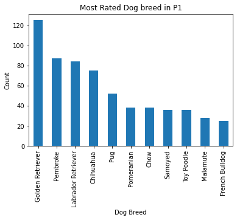

```python
# Histogram of the Most Rated Dog breed in P1
df_dog_breed = df.groupby('p1').filter(lambda x: len(x) >= 25)

df_dog_breed['p1'].value_counts().plot(kind = 'bar')
plt.title('Most Rated Dog breed in P1')
plt.xlabel('Dog Breed')
plt.ylabel('Count');
```

insight

- We have 369 dog breeds in P1 and Golden Retriever is the most predicted at 125

```python
# P1 breed where prediction true and confidence interval greater than 95%
d1 = df.groupby('p1').filter(lambda x: len(x) >= 1)[['p1','p1_conf','p1_dog']]
d1.loc[(df.p3_conf >= 1.00)]['p1'].value_counts()
```

```
Series([], Name: p1, dtype: int64)
```

```python
# P1 breed where prediction true and confidence interval greater than 95%
d1 = df.groupby('p1').filter(lambda x: len(x) >= 1)[['p1','p1_conf','p1_dog']]
d1.loc[(df.p1_dog == True)&(df.p1_conf >= 0.95)]['p1'].value_counts()
```

```
Pembroke                       19
Pug                            19
Samoyed                        17
Golden Retriever               14
Pomeranian                     13
Chihuahua                       9
French Bulldog                  8
Chow                            7
Labrador Retriever              5
Bernese Mountain Dog            4
German Shepherd                 4
Shetland Sheepdog               4
Beagle                          3
Pekinese                        3
Old English Sheepdog            3
Blenheim Spaniel                3
Boston Bull                     2
Cocker Spaniel                  2
English Springer                2
Keeshond                        2
Rottweiler                      2
Malamute                        2
Bull Mastiff                    2
Komondor                        2
Vizsla                          2
Basset                          2
Dalmatian                       2
Shih-Tzu                        2
Great Pyrenees                  1
Miniature Pinscher              1
Collie                          1
Cardigan                        1
Siberian Husky                  1
Saint Bernard                   1
Schipperke                      1
Briard                          1
Boxer                           1
Weimaraner                      1
Great Dane                      1
German Short-Haired Pointer     1
Toy Poodle                      1
Norwegian Elkhound              1
Maltese Dog                     1
Brittany Spaniel                1
Tibetan Mastiff                 1
Name: p1, dtype: int64
```

Insight

- Pembroke & Pug at 19 are the most predicted with 95% confidence interval

```python
# P1 breed where prediction is true
d1 = df.groupby('p1').filter(lambda x: len(x) >= 1)[['p1','p1_conf','p1_dog']]
d1.loc[(d1.p1_dog == True)]['p1'].value_counts()
```

```
Golden Retriever      125
Pembroke               87
Labrador Retriever     84
Chihuahua              75
Pug                    52
                     ...
Scotch Terrier          1
Entlebucher             1
Japanese Spaniel        1
Standard Schnauzer      1
Clumber                 1
Name: p1, Length: 111, dtype: int64
```

Golden Retriever most predicted at dog breed at 125

```python
# P1 breed where prediction is false
d1 = df.groupby('p1').filter(lambda x: len(x) >= 1)[['p1','p1_conf','p1_dog']]
d1.loc[(df.p1_dog == False)]['p1'].value_counts()
```

```
Seat Belt           20
Teddy               17
Web Site            15
Dingo                9
Tennis Ball          9
                    ..
Hammer               1
Nail                 1
Timber Wolf          1
Espresso             1
Desktop Computer     1
Name: p1, Length: 258, dtype: int64
```

Seat Belt at 20 is the most falsely predicted dog breed.

```python
# P1 breed where all the predictions are true
d1 = df.groupby('p1').filter(lambda x: len(x) >= 1)[['p1','p1_conf','p1_dog','p2','p2_conf','p2_dog','p3','p3_conf','p3_dog']]
d1.loc[(d1.p1_dog == True)&(d1.p2_dog == True)&(d1.p3_dog == True)]['p2'].value_counts()
```

```
Labrador Retriever    66
Cardigan              62
Golden Retriever      48
French Bulldog        30
Siberian Husky        30
                      ..
Mexican Hairless       1
Kerry Blue Terrier     1
Standard Schnauzer     1
Giant Schnauzer        1
Komondor               1
Name: p2, Length: 112, dtype: int64
```

### P2

```python
# Qauntitative analysis of P2
df['p2'].describe()
```

```
count                   1908
unique                   391
top       Labrador Retriever
freq                      88
Name: p2, dtype: object
```

Labrador Retriever is the most predicted P2 dog breed at 88 amongst 391 unique dog breeds.

```python
## Value counts of P2
df['p2'].value_counts()
```

```
Labrador Retriever          88
Cardigan                    72
Golden Retriever            70
Chihuahua                   41
Chesapeake Bay Retriever    39
                            ..
Coffee Mug                   1
Sombrero                     1
Handkerchief                 1
Dandie Dinmont               1
Mud Turtle                   1
Name: p2, Length: 391, dtype: int64
```

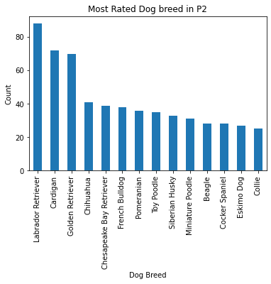

```python
df_dog_breed = df.groupby('p2').filter(lambda x: len(x) >= 25)

df_dog_breed['p2'].value_counts().plot(kind = 'bar')
plt.title('Most Rated Dog breed in P2')
plt.xlabel('Dog Breed')
plt.ylabel('Count');
```

```python
# P1 breed where prediction true and confidence interval greater than 95%
d1 = df.groupby('p2').filter(lambda x: len(x) >= 1)[['p2','p2_conf','p2_dog']]
d1.loc[(d1.p2_dog == True)&(d1.p2_conf >= 0.95)]['p2'].value_counts()
```

```
Series([], Name: p2, dtype: int64)
```

P2 doesnt have dog breeds with confidnce interval greater tha 95%

```python
# P2 breed where prediction is true
d1 = df.groupby('p2').filter(lambda x: len(x) >= 1)[['p2','p2_conf','p2_dog']]
d1.loc[(df.p2_conf >= 1.00)]['p2'].value_counts()
```

```
Series([], Name: p2, dtype: int64)
```

P2 doesnt have dog breeds with confidnce interval greater tha 100%

```python
# P2 breed where prediction is true
d1 = df.groupby('p2').filter(lambda x: len(x) >= 1)[['p2','p2_conf','p2_dog']]
d1.loc[(d1.p2_dog == True)]['p2'].value_counts()
```

```
Labrador Retriever          88
Cardigan                    71
Golden Retriever            70
Chihuahua                   41
Chesapeake Bay Retriever    39
                            ..
Japanese Spaniel             1
Affenpinscher                1
Entlebucher                  1
Bernese Mountain Dog         1
Komondor                     1
Name: p2, Length: 113, dtype: int64
```

As expected Labrador Retriever is the msot predcited P2 dog breed

```python
# P1 breed where prediction is false
d1 = df.groupby('p2').filter(lambda x: len(x) >= 1)[['p2','p2_conf','p2_dog']]
d1.loc[(df.p2_dog == False)]['p2'].value_counts()
```

```
Teddy          11
Doormat        10
Siamese Cat    10
Ice Bear        9
Seat Belt       9
               ..
Minibus         1
Screw           1
Coffee Mug      1
Sombrero        1
Mud Turtle      1
Name: p2, Length: 279, dtype: int64
```

Teddy(11), Doormat & Siamese Cat both 10 are the most falsely predicted dog breed in P2

```python
# P1 breed where all the predictions are true
d1 = df.groupby('p2').filter(lambda x: len(x) >= 1)[['p1','p1_conf','p1_dog','p2','p2_conf','p2_dog','p3','p3_conf','p3_dog']]
d1.loc[(d1.p1_dog == True)&(d1.p2_dog == True)&(d1.p3_dog == True)]['p2'].value_counts()
```

```
Labrador Retriever    66
Cardigan              62
Golden Retriever      48
French Bulldog        30
Siberian Husky        30
                      ..
Mexican Hairless       1
Kerry Blue Terrier     1
Standard Schnauzer     1
Giant Schnauzer        1
Komondor               1
Name: p2, Length: 112, dtype: int64
```

Labrador Retriever (66) and Cardigan(62) are the most predicted in all the image predictions of P2 same as P1.

### P3

```python
# Qauntitative analysis of P1
df['p3'].describe()
```

```
count                   1908
unique                   401
top       Labrador Retriever
freq                      72
Name: p3, dtype: object
```

```python
#len()
df['p3'].value_counts()
```

```
Labrador Retriever     72
Chihuahua              56
Golden Retriever       43
Eskimo Dog             34
Kelpie                 31
                       ..
Rotisserie              1
King Penguin            1
Hand Blower             1
American Black Bear     1
Partridge               1
Name: p3, Length: 401, dtype: int64
```

```python
# Filter values of P1 greater than 25
df.groupby('p3').filter(lambda x: len(x) >= 25)
```

|  | tweet_id | full_text | name | stage | rating_ratio | retweet_count | favorite_count | rating_numerator | rating_denominator | img_num | ... | p2 | p2_conf | p2_dog | p3 | p3_conf | p3_dog | date | time | source | jpg_url |
| --- | --- | --- | --- | --- | --- | --- | --- | --- | --- | --- | --- | --- | --- | --- | --- | --- | --- | --- | --- | --- | --- |
| 2 | 891815181378084864 | This is Archie. He is a rare Norwegian Pouncin... | Archie | NaN | 1.2 | 3488 | 22088 | 12.0 | 10.0 | 1 | ... | Malamute | 0.078253 | True | Kelpie | 0.031379 | True | 2017-07-31 | 00:18:03 | Twitter for iPhone | https://pbs.twimg.com/media/DGBdLU1WsAANxJ9.jpg |
| 7 | 890729181411237888 | When you watch your owner call another dog a g... | NaN | NaN | 1.3 | 15784 | 56913 | 13.0 | 10.0 | 2 | ... | Eskimo Dog | 0.178406 | True | Pembroke | 0.076507 | True | 2017-07-28 | 00:22:40 | Twitter for iPhone | https://pbs.twimg.com/media/DFyBahAVwAAhUTd.jpg |
| 9 | 890240255349198849 | This is Cassie. She is a college pup. Studying... | Cassie | doggo | 1.4 | 6108 | 27989 | 14.0 | 10.0 | 1 | ... | Cardigan | 0.451038 | True | Chihuahua | 0.029248 | True | 2017-07-26 | 15:59:51 | Twitter for iPhone | https://pbs.twimg.com/media/DFrEyVuW0AAO3t9.jpg |
| 10 | 890006608113172480 | This is Koda. He is a South Australian decksha... | Koda | NaN | 1.3 | 6159 | 27075 | 13.0 | 10.0 | 1 | ... | Pomeranian | 0.013884 | True | Chow | 0.008167 | True | 2017-07-26 | 00:31:25 | Twitter for iPhone | https://pbs.twimg.com/media/DFnwSY4WAAAMliS.jpg |
| 13 | 889638837579907072 | This is Ted. He does his best. Sometimes that'... | Ted | NaN | 1.2 | 3721 | 23714 | 12.0 | 10.0 | 1 | ... | Boxer | 0.002129 | True | Staffordshire Bullterrier | 0.001498 | True | 2017-07-25 | 00:10:02 | Twitter for iPhone | https://pbs.twimg.com/media/DFihzFfXsAYGDPR.jpg |
| ... | ... | ... | ... | ... | ... | ... | ... | ... | ... | ... | ... | ... | ... | ... | ... | ... | ... | ... | ... | ... | ... |
| 1883 | 666353288456101888 | Here we have a mixed Asiago from the Galápagos... | NaN | NaN | 0.8 | 58 | 179 | 8.0 | 10.0 | 1 | ... | Siberian Husky | 0.147655 | True | Eskimo Dog | 0.093412 | True | 2015-11-16 | 20:32:58 | Twitter for iPhone | https://pbs.twimg.com/media/CT9cx0tUEAAhNN_.jpg |
| 1884 | 666345417576210432 | Look at this jokester thinking seat belt laws ... | NaN | NaN | 1.0 | 126 | 246 | 10.0 | 10.0 | 1 | ... | Chesapeake Bay Retriever | 0.054787 | True | Labrador Retriever | 0.014241 | True | 2015-11-16 | 20:01:42 | Twitter for iPhone | https://pbs.twimg.com/media/CT9Vn7PWoAA_ZCM.jpg |
| 1896 | 666071193221509120 | Here we have a northern speckled Rhododendron.... | NaN | NaN | 0.9 | 51 | 127 | 9.0 | 10.0 | 1 | ... | Yorkshire Terrier | 0.174201 | True | Pekinese | 0.109454 | True | 2015-11-16 | 01:52:02 | Twitter for iPhone | https://pbs.twimg.com/media/CT5cN_3WEAAlOoZ.jpg |
| 1897 | 666063827256086533 | This is the happiest dog you will ever see. Ve... | NaN | NaN | 1.0 | 181 | 400 | 10.0 | 10.0 | 1 | ... | Tibetan Mastiff | 0.093718 | True | Labrador Retriever | 0.072427 | True | 2015-11-16 | 01:22:45 | Twitter for iPhone | https://pbs.twimg.com/media/CT5Vg_wXIAAXfnj.jpg |
| 1899 | 666057090499244032 | My oh my. This is a rare blond Canadian terrie... | NaN | NaN | 0.9 | 112 | 249 | 9.0 | 10.0 | 1 | ... | Shopping Basket | 0.014594 | False | Golden Retriever | 0.007959 | True | 2015-11-16 | 00:55:59 | Twitter for iPhone | https://pbs.twimg.com/media/CT5PY90WoAAQGLo.jpg |

457 rows × 23 columns

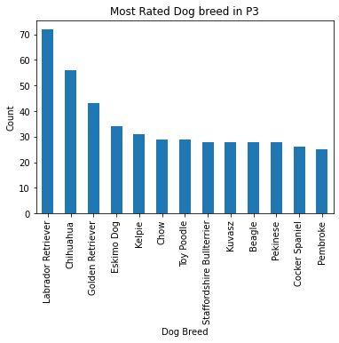

```python
df_dog_breed = df.groupby('p3').filter(lambda x: len(x) >= 25)

df_dog_breed['p3'].value_counts().plot(kind = 'bar')
plt.title('Most Rated Dog breed in P3')
plt.xlabel('Dog Breed')
plt.ylabel('Count');
```

```python
# P1 breed where prediction true and confidence interval greater than 95%
d1 = df.groupby('p3').filter(lambda x: len(x) >= 1)[['p3','p3_conf','p3_dog']]
d1.loc[(df.p3_dog == True)&(df.p3_conf >= 0.95)]['p3'].value_counts()
```

```
Series([], Name: p3, dtype: int64)
```

P3 doesnt have dog breeds with confidence interval greater tha 95%

```python
# P1 breed where prediction true and confidence interval greater than 95%
d1 = df.groupby('p3').filter(lambda x: len(x) >= 1)[['p3','p3_conf','p3_dog']]
d1.loc[(df.p3_conf >= 1.00)]['p3'].value_counts()
```

```
Series([], Name: p3, dtype: int64)
```

P3 doesnt have dog breeds with confidnce interval greater than 100%

```python
# P1 breed where prediction is true
d1 = df.groupby('p3').filter(lambda x: len(x) >= 1)[['p3','p3_conf','p3_dog']]
d1.loc[(d1.p3_dog == True)]['p3'].value_counts()
```

```
Labrador Retriever    72
Chihuahua             56
Golden Retriever      43
Eskimo Dog            34
Kelpie                31
                      ..
Briard                 2
Sussex Spaniel         1
Affenpinscher          1
Standard Schnauzer     1
Kerry Blue Terrier     1
Name: p3, Length: 116, dtype: int64
```

As expected Labrador Retriever is the msot predcited P3 dog breed

```python
# P1 breed where prediction is false
d1 = df.groupby('p3').filter(lambda x: len(x) >= 1)[['p3','p3_conf','p3_dog']]
d1.loc[(df.p3_dog == False)]['p3'].value_counts()
```

```
Dingo                  15
Doormat                12
Siamese Cat            12
Teddy                  11
Seat Belt              11
                       ..
Hand Blower             1
American Black Bear     1
Viaduct                 1
Spatula                 1
Partridge               1
Name: p3, Length: 285, dtype: int64
```

Dingo(15), Doormat & Siamese Cat both 12 are the most falsely predicted dog breed in P3

```python
# P1 breed where all the predictions are true
d1 = df.groupby('p3').filter(lambda x: len(x) >= 1)[['p1','p1_conf','p1_dog','p2','p2_conf','p2_dog','p3','p3_conf','p3_dog']]
d1.loc[(d1.p1_dog == True)&(d1.p2_dog == True)&(d1.p3_dog == True)]['p3'].value_counts()
```

```
Labrador Retriever      59
Chihuahua               47
Golden Retriever        31
Eskimo Dog              30
Pekinese                26
                        ..
Bernese Mountain Dog     1
Standard Schnauzer       1
Kerry Blue Terrier       1
Komondor                 1
Affenpinscher            1
Name: p3, Length: 116, dtype: int64
```

Labrador Retriever (59) and Chihuahua (47) are the most predicted in all the image predictions of P3

```python
# Qauntitative analysis of P1,P2,P3
df.loc[:,['p1','p2','p3']].describe()
```

|  | p1 | p2 | p3 |
| --- | --- | --- | --- |
| count | 1908 | 1908 | 1908 |
| unique | 369 | 391 | 401 |
| top | Golden Retriever | Labrador Retriever | Labrador Retriever |
| freq | 125 | 88 | 72 |

### Insight 1

```python
# Qauntitative analysis of P1,P2,P3
df.loc[:,['p1_conf','p2_conf','p3_conf']].describe()
```

|  | p1_conf | p2_conf | p3_conf |
| --- | --- | --- | --- |
| count | 1908.000000 | 1.908000e+03 | 1.908000e+03 |
| mean | 0.592905 | 1.343463e-01 | 6.025894e-02 |
| std | 0.273197 | 1.006359e-01 | 5.095809e-02 |
| min | 0.044333 | 1.011300e-08 | 1.740170e-10 |
| 25% | 0.359779 | 5.419487e-02 | 1.609287e-02 |
| 50% | 0.587222 | 1.172595e-01 | 4.967815e-02 |
| 75% | 0.847063 | 1.948745e-01 | 9.157912e-02 |
| max | 1.000000 | 4.880140e-01 | 2.734190e-01 |

```python
# P1 breed where confidence interval is greater pr equal to 1
d1 = df.groupby('p1').filter(lambda x: len(x) >= 1)[['p1','p1_conf','p1_dog']]
d1.loc[(df.p1_conf >= 1.00)]['p1'].value_counts()
```

```
Jigsaw Puzzle    1
Name: p1, dtype: int64
```

```python
df[df['p1_conf'] >= 1.00][['p1','p1_conf','p1_dog']]
```

|  | p1 | p1_conf | p1_dog |
| --- | --- | --- | --- |
| 1804 | Jigsaw Puzzle | 1.0 | False |

```python
df[df['p2_conf'] >= 1.00][['p2','p2_conf','p2_dog']]
```

|  | p2 | p2_conf | p2_dog |
| --- | --- | --- | --- |

```python
df[df['p3_conf'] >= 1.00][['p3','p3_conf','p3_dog']]
```

|  | p3 | p3_conf | p3_dog |
| --- | --- | --- | --- |

```python
df[df['p1_conf'] >= 1.00]
```

|  | tweet_id | full_text | name | stage | rating_ratio | retweet_count | favorite_count | rating_numerator | rating_denominator | img_num | ... | p2 | p2_conf | p2_dog | p3 | p3_conf | p3_dog | date | time | source | jpg_url |
| --- | --- | --- | --- | --- | --- | --- | --- | --- | --- | --- | --- | --- | --- | --- | --- | --- | --- | --- | --- | --- | --- |
| 1804 | 667866724293877760 | This is Shaggy. He knows exactly how to solve ... | Shaggy | NaN | 1.0 | 902 | 2722 | 10.0 | 10.0 | 1 | ... | Prayer Rug | 1.011300e-08 | False | Doormat | 1.740170e-10 | False | 2015-11-21 | 00:46:50 | Twitter for iPhone | https://pbs.twimg.com/media/CUS9PlUWwAANeAD.jpg |

1 rows × 23 columns

### Insight

Jigsaw Puzzle was the onl;y breed in the image predctions to score 100% confidence interval, unfortunately the predcitor was wrong. Showing we cant rely on 100% confidence interval to use in our prediction.

```python
df['p1_conf'].describe()
```

```
count    1908.000000
mean        0.592905
std         0.273197
min         0.044333
25%         0.359779
50%         0.587222
75%         0.847063
max         1.000000
Name: p1_conf, dtype: float64
```

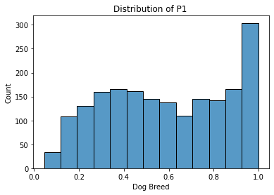

```python
g = sns.histplot(df, x="p1_conf")
plt.title('Distribution of P1 ')
plt.xlabel('Dog Breed')
plt.ylabel('Count');
```

P1 confidence interval distribution shows a normal distribution from 0% to 70% before sharply skewing to the left. There is a lot of high confidnce interval values in the P1 prediction. The model used was confident in the image predictions.

```python
df['p2_conf'].describe()
```

```
count    1.908000e+03
mean     1.343463e-01
std      1.006359e-01
min      1.011300e-08
25%      5.419487e-02
50%      1.172595e-01
75%      1.948745e-01
max      4.880140e-01
Name: p2_conf, dtype: float64
```

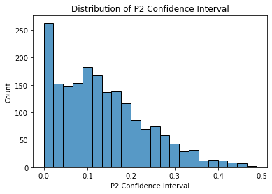

```python
g = sns.histplot(df, x="p2_conf")
plt.title('Distribution of P2 Confidence Interval')
plt.xlabel('P2 Confidence Interval')
plt.ylabel('Count');
```

P2 confidence interval distribution shows a right skewed distribution. This is due toa lot of low confidnce interval values in the P2 prediction. The model used was not confident in the image predictions with almost all the prediction below 50% confidence interval.

```python
df['p3_conf'].describe()
```

```
count    1.908000e+03
mean     6.025894e-02
std      5.095809e-02
min      1.740170e-10
25%      1.609287e-02
50%      4.967815e-02
75%      9.157912e-02
max      2.734190e-01
Name: p3_conf, dtype: float64
```

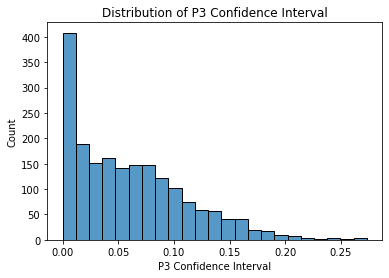

```python
g = sns.histplot(df, x="p3_conf")
plt.title('Distribution of P3 Confidence Interval')
plt.xlabel('P3 Confidence Interval')
plt.ylabel('Count');
```

P3 confidence interval distribution shows a right skewed distribution same as P2. This is due to a lot of low confidence interval values in the P3 prediction. The model used was not confident in the image predictions with almost all the prediction below 25% confidence interval.

### Insight 2:

**The model used was most confident of P1 image predictions.**

## Analysis 2

### retweets and likes

```python
# retweet vs likes statistical analysis.
df.loc[:,['retweet_count','favorite_count']].describe()
```

|  | retweet_count | favorite_count |
| --- | --- | --- |
| count | 1908.000000 | 1908.000000 |
| mean | 2049.387317 | 7226.901468 |
| std | 3629.863505 | 10658.512672 |
| min | 11.000000 | 66.000000 |
| 25% | 481.750000 | 1565.000000 |
| 50% | 1034.500000 | 3304.500000 |
| 75% | 2339.500000 | 8778.000000 |
| max | 70907.000000 | 145012.000000 |

- The minimum retweets(retweet_count) received by a tweet is 11 with maximum being 70907
- The minimum likes(favorite_count) received by a tweet is 66 with maximum being 145012

The average retweets 2049 and likes is 7227.The likes average is higher because people are likely to like a picture than retweet it.

The average for both retweets and likes is greater than their median values 1035 and 3305 respectively.This will cause the distribution of these variables to skew to the right.

```python
# lowest retweet count
df[df['retweet_count'] == 11 ]
```

|  | tweet_id | full_text | name | stage | rating_ratio | retweet_count | favorite_count | rating_numerator | rating_denominator | img_num | ... | p2 | p2_conf | p2_dog | p3 | p3_conf | p3_dog | date | time | source | jpg_url |
| --- | --- | --- | --- | --- | --- | --- | --- | --- | --- | --- | --- | --- | --- | --- | --- | --- | --- | --- | --- | --- | --- |
| 1891 | 666102155909144576 | Oh my. Here you are seeing an Adobe Setter giv... | NaN | NaN | 1.1 | 11 | 66 | 11.0 | 10.0 | 1 | ... | Newfoundland | 0.149842 | True | Borzoi | 0.133649 | True | 2015-11-16 | 03:55:04 | Twitter for iPhone | https://pbs.twimg.com/media/CT54YGiWUAEZnoK.jpg |

1 rows × 23 columns

```python
# highest retweet count
df[df['retweet_count'] == 70907 ]
```

|  | tweet_id | full_text | name | stage | rating_ratio | retweet_count | favorite_count | rating_numerator | rating_denominator | img_num | ... | p2 | p2_conf | p2_dog | p3 | p3_conf | p3_dog | date | time | source | jpg_url |
| --- | --- | --- | --- | --- | --- | --- | --- | --- | --- | --- | --- | --- | --- | --- | --- | --- | --- | --- | --- | --- | --- |
| 724 | 744234799360020481 | Here's a doggo realizing you can stand in a po... | NaN | doggo | 1.3 | 70907 | 145012 | 13.0 | 10.0 | 1 | ... | Ice Bear | 0.044681 | False | Whippet | 0.018442 | True | 2016-06-18 | 18:26:18 | Twitter for iPhone | https://pbs.twimg.com/ext_tw_video_thumb/74423... |

1 rows × 23 columns

```python
# lowest favorite count
df[df['favorite_count'] == 66 ]
```

|  | tweet_id | full_text | name | stage | rating_ratio | retweet_count | favorite_count | rating_numerator | rating_denominator | img_num | ... | p2 | p2_conf | p2_dog | p3 | p3_conf | p3_dog | date | time | source | jpg_url |
| --- | --- | --- | --- | --- | --- | --- | --- | --- | --- | --- | --- | --- | --- | --- | --- | --- | --- | --- | --- | --- | --- |
| 1891 | 666102155909144576 | Oh my. Here you are seeing an Adobe Setter giv... | NaN | NaN | 1.1 | 11 | 66 | 11.0 | 10.0 | 1 | ... | Newfoundland | 0.149842 | True | Borzoi | 0.133649 | True | 2015-11-16 | 03:55:04 | Twitter for iPhone | https://pbs.twimg.com/media/CT54YGiWUAEZnoK.jpg |

1 rows × 23 columns

```python
# highest favorite count
df[df['favorite_count'] == 	145012 ]
```

|  | tweet_id | full_text | name | stage | rating_ratio | retweet_count | favorite_count | rating_numerator | rating_denominator | img_num | ... | p2 | p2_conf | p2_dog | p3 | p3_conf | p3_dog | date | time | source | jpg_url |
| --- | --- | --- | --- | --- | --- | --- | --- | --- | --- | --- | --- | --- | --- | --- | --- | --- | --- | --- | --- | --- | --- |
| 724 | 744234799360020481 | Here's a doggo realizing you can stand in a po... | NaN | doggo | 1.3 | 70907 | 145012 | 13.0 | 10.0 | 1 | ... | Ice Bear | 0.044681 | False | Whippet | 0.018442 | True | 2016-06-18 | 18:26:18 | Twitter for iPhone | https://pbs.twimg.com/ext_tw_video_thumb/74423... |

1 rows × 23 columns

### Insight 3

**The tweet than recieved the most retweets also received the most likes (tweet id - 744234799360020481 https://t.co/7wE9LTEXC4) and the reverse is also true for least( tweet id - 666102155909144576 https://t.co/11LvqN4WLq). The most liked and retweeted photo did not recieve the highest rating than the least liked and retweeted.**

```python
# Removing outliers using the IQR method
percentile_25 = df.retweet_count.quantile(0.25)
percentile_75 = df.retweet_count.quantile(0.75)

iqr = percentile_75 - percentile_25
# lower outlier
low_outlier1 = percentile_25 - (1.5 * iqr)
# high outlier
high_outlier1 = percentile_75 + (1.5 * iqr)
iqr,low_outlier1,high_outlier1
```

```
(1857.75, -2304.875, 5126.125)
```

```python
len(df[df['retweet_count'] < low_outlier1])
```

```
0
```

```python
len(df[df['retweet_count'] > high_outlier1])
```

```
156
```

retweet count has 156 outliers

```python
# Removing outliers using the IQR method
percentile_25 = df.favorite_count.quantile(0.25)
percentile_75 = df.favorite_count.quantile(0.75)

iqr = percentile_75 - percentile_25
# lower outlier
low_outlier2 = percentile_25 - (1.5 * iqr)
# high outlier
high_outlier2 = percentile_75 + (1.5 * iqr)
iqr,low_outlier2,high_outlier2
```

```
(7213.0, -9254.5, 19597.5)
```

```python
len(df[df['favorite_count'] < low_outlier2])
```

```
0
```

```python
len(df[df['favorite_count'] > high_outlier2])
```

```
177
```

favorite count has 177 outliers

```python
# Removing outliers using the IQR method
percentile_25 = df.favorite_count.quantile(0.25)
percentile_75 = df.favorite_count.quantile(0.75)

iqr = percentile_75 - percentile_25
# lower outlier
low_outlier = percentile_25 - (1.5 * iqr)
# high outlier
high_outlier = percentile_75 + (1.5 * iqr)
iqr,low_outlier,high_outlier
```

```
(7213.0, -9254.5, 19597.5)
```

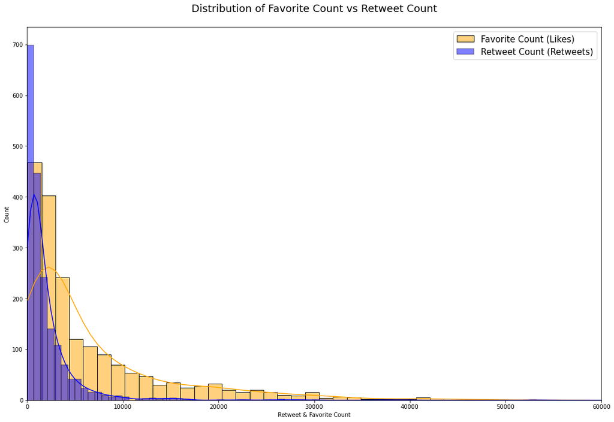

```python
# Histogram of favorite_count and retweet_count
plt.figure(figsize=(18,12))
ax = sns.histplot(data=df,x='favorite_count',kde=True, color = "orange", bins=100, label='Favorite Count (Likes)')
ax = sns.histplot(data=df,x='retweet_count',kde=True, color = "blue", bins=100, label='Retweet Count (Retweets)')
ax.set_xlabel('Retweet & Favorite Count')
ax.set_ylabel('Count')
plt.title('Distribution of Favorite Count vs Retweet Count\n', size = 18)
plt.legend(loc='upper right', fontsize = 15)
plt.xlim(0,60000)
plt.show();
```

Looking at both the histograms of favorite_count and retweet_count, they are both skewed to the right mean that there is a large concentration of lower bound values and the existence of outliers as analysed above.

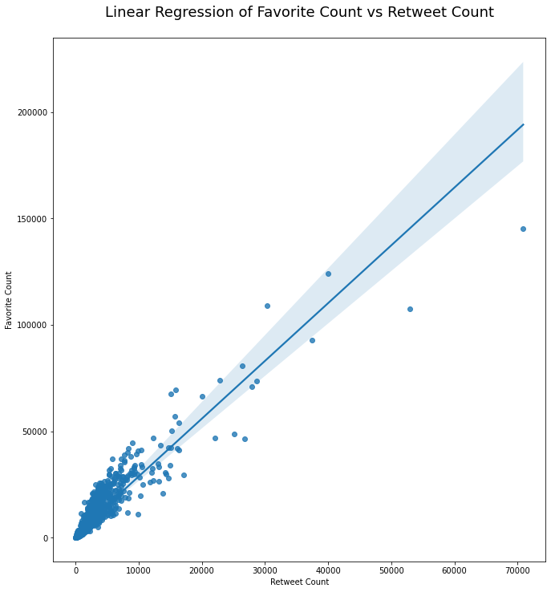

```python
# Regression plot of retweet count and favorite count
fig, ax = plt.subplots(figsize=(11,12))
sns.regplot(data=df,x='retweet_count',y='favorite_count')
ax.set_xlabel('Retweet Count')
ax.set_ylabel('Favorite Count')
plt.title('Linear Regression of Favorite Count vs Retweet Count\n', size = 18)
plt.show()
```

### Insight 4

**There is a positive relationship between Retweet_count & Favorite_count. This means that as Retweet_count increases,Favorite_count also increase. This is likely due to the fact that poeple who like tweets are more likely to retweets that tweet. There is also some existence of outliers as mentioned before(above) they might need to be dealt with if planning of building a model building as they have the abilty to skew results.**

## Analysis 3

### Ratings Extreme Outliers

```python
df.rating_ratio.describe()
```

```
count    1908.000000
mean        1.164873
std         4.154405
min         0.000000
25%         1.000000
50%         1.100000
75%         1.200000
max       177.600000
Name: rating_ratio, dtype: float64
```

```python
df.rating_ratio.value_counts().sort_index()
```

```
0.000        2
0.100        4
0.200        9
0.300       19
0.400       14
0.500       32
0.600       32
0.700       51
0.800       95
0.900      151
0.975        1
1.000      410
1.100      381
1.126        1
1.127        1
1.200      429
1.300      240
1.350        1
1.400       33
42.000       1
177.600      1
Name: rating_ratio, dtype: int64
```

```python
# Removing outliers using the IQR method
percentile_25 = df.rating_ratio.quantile(0.25)
percentile_75 = df.rating_ratio.quantile(0.75)

iqr = percentile_75 - percentile_25
# lower outlier
low_outlier = percentile_25 - (1.5 * iqr)
# high outlier
high_outlier = percentile_75 + (1.5 * iqr)
iqr,low_outlier,high_outlier
```

```
(0.19999999999999996, 0.7000000000000001, 1.5)
```

lowest outlier rating = 0.7 and highest outlier rating = 1.5

```python
len(df[df['rating_ratio'] < low_outlier])
```

```
163
```

```python
len(df[df['rating_ratio'] > high_outlier])
```

```
2
```

```python
df[df['rating_ratio'] > high_outlier]
```

|  | tweet_id | full_text | name | stage | rating_ratio | retweet_count | favorite_count | rating_numerator | rating_denominator | img_num | ... | p2 | p2_conf | p2_dog | p3 | p3_conf | p3_dog | date | time | source | jpg_url |
| --- | --- | --- | --- | --- | --- | --- | --- | --- | --- | --- | --- | --- | --- | --- | --- | --- | --- | --- | --- | --- | --- |
| 675 | 749981277374128128 | This is Atticus. He's quite simply America af.... | Atticus | NaN | 177.6 | 2281 | 4791 | 1776.0 | 10.0 | 1 | ... | Sunglasses | 0.080822 | False | Sunglass | 0.050776 | False | 2016-07-04 | 15:00:45 | TweetDeck | https://pbs.twimg.com/media/CmgBZ7kWcAAlzFD.jpg |
| 1635 | 670842764863651840 | After so many requests... here you go.\n\nGood... | NaN | NaN | 42.0 | 7592 | 22111 | 420.0 | 10.0 | 1 | ... | Accordion | 0.094075 | False | Drumstick | 0.061113 | False | 2015-11-29 | 05:52:33 | Twitter for iPhone | https://pbs.twimg.com/media/CU9P717W4AAOlKx.jpg |

2 rows × 23 columns

```python
outliers = len(df[df['rating_ratio'] < low_outlier]) + len(df[df['rating_ratio'] > high_outlier])
outliers
```

```
165
```

```python
total = len(df['rating_ratio'])
total
```

```
1908
```

```python
# Percentage of outliers
outliers/total *100
```

```
8.647798742138365
```

9 % of the ratings are outliers, this a significant number of observations to drop them all.

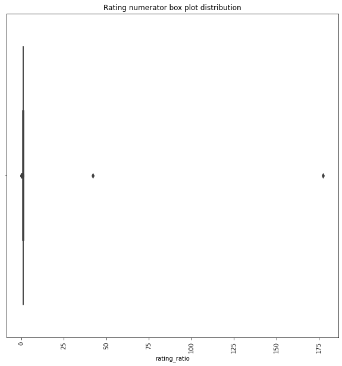

```python
# boxplot for rating numerator
plt.figure(figsize=(10,10))
plt.xticks(rotation=90)
g = sns.boxplot(x=df.rating_ratio)
g.set(title='Rating numerator box plot distribution');
```

```python
df.rating_ratio.describe()
```

```
count    1908.000000
mean        1.164873
std         4.154405
min         0.000000
25%         1.000000
50%         1.100000
75%         1.200000
max       177.600000
Name: rating_ratio, dtype: float64
```

```python
# dropping the values of age that are considered outliers
#df1.drop(df1[df1['rating_numerator'] < low_outlier].index, inplace = True)
df.drop(df[df['rating_ratio'] > high_outlier].index, inplace = True)
```

```python
df.rating_ratio.describe()
```

```
count    1906.00000
mean        1.05088
std         0.21909
min         0.00000
25%         1.00000
50%         1.10000
75%         1.20000
max         1.40000
Name: rating_ratio, dtype: float64
```

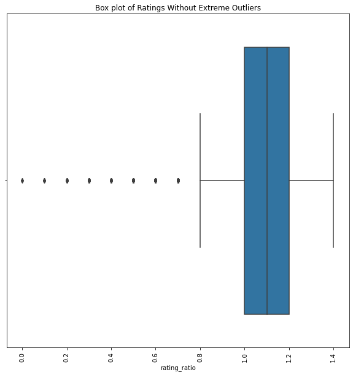

```python
# boxplot for age
plt.figure(figsize=(10,10))
plt.xticks(rotation=90)
p = sns.boxplot(x=df.rating_ratio )
p.set(title='Box plot of Ratings Without Extreme Outliers')
plt.show()
```

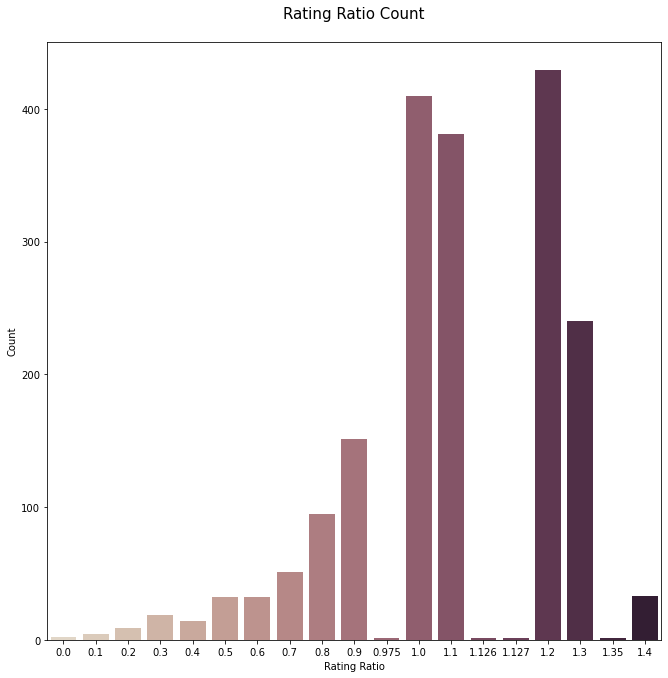

```python
plt.figure(figsize=(11,11))
p = sns.countplot(data=df, x='rating_ratio', palette = "ch:.25")
p.set_xlabel('Rating Ratio')
p.set_ylabel('Count')
plt.title('Rating Ratio Count\n', size = 15)
plt.show()
```

Ratings 1.0 and 1.2 are the most popular ratings

## Analysis 4

### Ratings vs Retweets and Likes

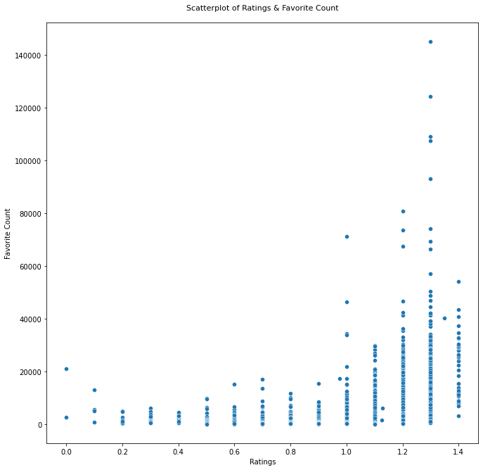

```python
plt.figure(figsize=(11,11))
a = sns.scatterplot(data=df,x='rating_ratio',y='favorite_count')
a.set_xlabel('Ratings')
a.set_ylabel('Favorite Count')
plt.title('Scatterplot of Ratings & Favorite Count\n', size = 11)
plt.show();
```

The lowest rated tweets recieved the lowest likes and 1.3 is the most liked rating.

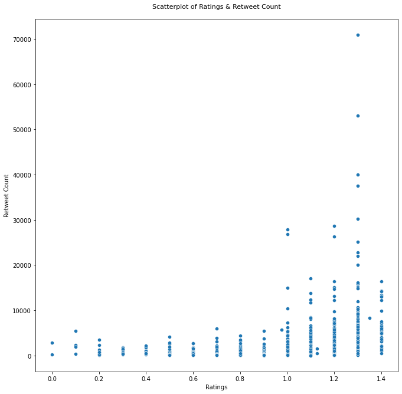

```python
plt.figure(figsize=(11,11))
b = sns.scatterplot(data=df,x='rating_ratio',y='retweet_count')
b.set_xlabel('Ratings')
b.set_ylabel('Retweet Count')
plt.title('Scatterplot of Ratings & Retweet Count\n', size = 11)
plt.show();
```

The lowest rated tweets recieved the lowest retweets and 1.3 is the most retweeted rating.

### Insight 5

**The lowest rated tweets recieved the lowest likes and retweets and 1.3 is the most liked and retweeted rating.**

## Analysis 5

### source and ratings ,retweets and likes

```python
df.source.value_counts()
```

```
Twitter for iPhone    1871
Twitter Web Client      26
TweetDeck                9
Name: source, dtype: int64
```

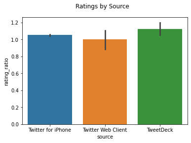

```python
p=sns.barplot(data=df, x='source', y='rating_ratio')
p.figure.suptitle('Ratings by Source');
```

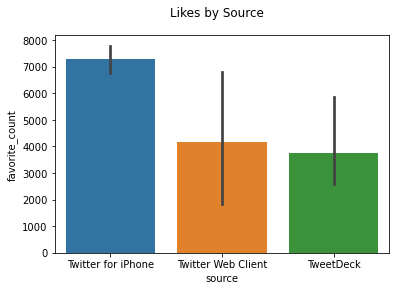

```python
p=sns.barplot(data=df, x='source', y='favorite_count')
p.figure.suptitle('Likes by Source');
```

Twitter by Iphone users are likely to get likes (favorite) on their tweets with the avearge being around 7000 likes.

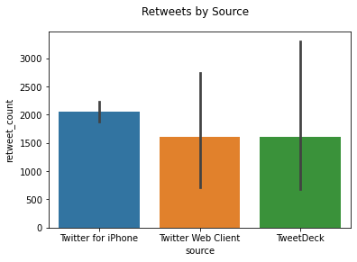

```python
p=sns.barplot(data=df, x='source', y='retweet_count')
p.figure.suptitle('Retweets by Source');
```

Twitter by Iphone users are likely to get retweets on their tweets with the avearge being around 2000 retweets.

### Insight 6

**Twitter by Iphone users are likely to get more retweets and likes on their tweets.**

## Analysis 6

### Correlations (Heatmap)

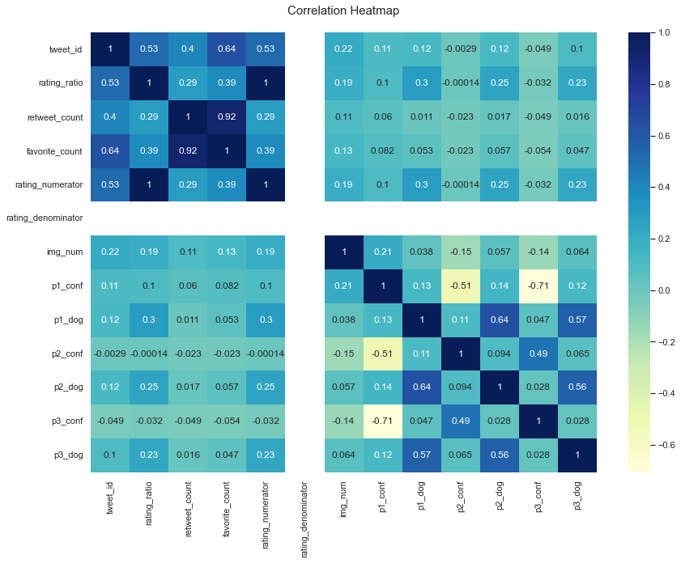

```python
# plotting correlation heatmap of the whole dataset
plt.figure(figsize=(14,10))
sns.set(style='white')
dataplot = sns.heatmap(df.corr(), cmap="YlGnBu", annot=True)
plt.title('Correlation Heatmap\n', size = 15)
plt.show()
```

### Insight

- rating_ratio and ratio_numerator have a correlation of 1 because one is based on another.
- There is a strong positive correlation between retweet_count and favorite_count (0.92) as mentioned in analysis 2.
- There is negative correlation between p1_conf and both p2_conf (-0.51) and p3_conf (-0.71), this might be due to prediction model having a high confidence in P1 results compared to P2 and P3 results.